# Source for the Data

## Source for the Data

Data for this document can be found here: [Activity monitoring dataset](https://d396qusza40orc.cloudfront.net/repdata%2Fdata%2Factivity.zip)  
Alternatively, a zipfile `activity.zip` containing the data is present in the repository itself.

## Loading and preprocessing the data

Load the data from the csv file. Change the file path to where the data file is located.

```r
filePath <- "../" # change this to to where the data is located on your system
fullPath <- paste("../", "activity.csv", sep = "")
rawData <- read.csv(fullPath, header = TRUE, stringsAsFactors = FALSE)

## convert the date column into the right format
rawData$date <- as.Date(rawData$date)

## create dataset removing NA values
cleanData <- subset(rawData, is.na(rawData$steps) == FALSE)
```

## What is mean total number of steps taken per day?

First, we calculate the total number of steps taken per day and plot its histogram.

```r
## create vector of steps per day using dates information
options(scipen=999)

## using date as a factor to sum total steps (per day)
stepPerDay <- tapply(X = cleanData$steps,INDEX = cleanData$date, FUN = sum)

## calculating mean and median values
meanSteps <- round(mean(stepPerDay),digits = 2)
medianSteps <- median(stepPerDay)
```

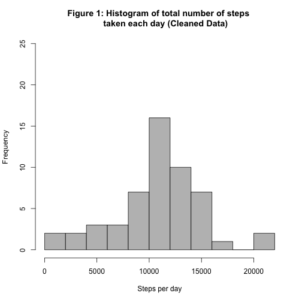

```r
## plot the histogram of total number of steps taken per day
hist(stepPerDay,xlab = "Steps per day",
     main = "Figure 1: Histogram of total number of steps
     taken each day (Cleaned Data)", breaks = 10,
     col = "grey",ylim = c(0,25))
```

The data for total number of steps per day has a mean of **10766.19** and a median of **10765**.

## What is the average daily activity pattern?

First, we calculate the average number of steps (across all days) taken within a time interval.

```r
## calculating the average steps for each interval (across dates), using steps as
## a factor
meanByInterval <- tapply(cleanData$steps,INDEX = cleanData$interval, FUN = mean)
intervals <- unique(cleanData$interval)
```

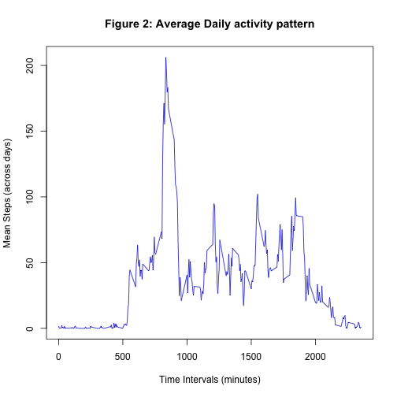

```r
## constructing a time series plot to denote the activity (steps) on an 'average' day
plot(x = intervals, y = meanByInterval, type = 'l',
     xlab = "Time Intervals (minutes)", ylab = "Mean Steps (across days)", main = "Figure 2: Average Daily activity pattern", col = "blue3")
```

```r
## calculating the time interval with max average steps
maxStepsInterval <- intervals[which.max(meanByInterval)]
```

The 5-minute interval, on average across all the days in the dataset, that contains the maximum number of steps is the **835th** interval.

## Imputing missing values

The dataset contains several NA values. In order to impute these values, we first calculate the total number of rows with NA values for steps.

```r
naRows <- sum(is.na(rawData$steps))
```

There are **2304 rows** that contain NA values for steps.  
To impute these values, we

- Use the **means** for each time `interval` across all dates and
- Replace the NA values depending on the time interval they refer too

```r
intervalMeanValues <- as.data.frame(cbind(intervals, meanByInterval))

imputedData <- rawData
for (i in 1:nrow(imputedData)){
    if (is.na(imputedData[i,1]) == T){
        currentInterval <- imputedData[i,3]
        ## Replace NA value with the mean calculated for the interval
        imputedData[i,1]<- intervalMeanValues[intervals == currentInterval, 2]
    }
}
```

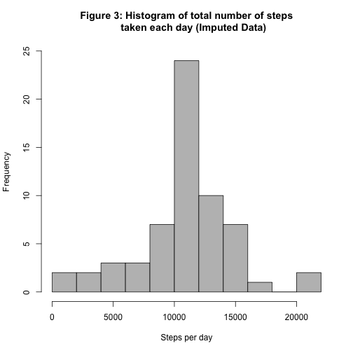

```r
## plotting a histogram of the total number of steps taken each day
impstepPerDay <- tapply(X = imputedData$steps,INDEX = imputedData$date, FUN = sum)
impmeanSteps <- round(mean(impstepPerDay),digits = 2)
impmedianSteps <- round(median(impstepPerDay), digits = 2)
## plot the histogram of total number of steps taken per day
hist(impstepPerDay,xlab = "Steps per day",
     main = "Figure 3: Histogram of total number of steps
     taken each day (Imputed Data)", breaks = 10,
     col = "grey", ylim = c(0,25))
```

Based on the imputed dataset, the histogram for total number of steps per day has a mean of **10766.19** and a median of **10766.19**.

If we compare *Figure 1* and *Figure 3*, we can see that the overall shape of the histogram has been preserved, with more data being added in *Figure 3*.

### Difference from results obtained while excluding missing values

Comparing the above results with the mean of **10766.19** and median of **10765** obtained with the dataset excluding NA values we see that:

1. **Mean** of total number of steps per day remains the same
2. **Median** of toal number of steps per day is slightly higher for the imputed data than the clean data. It is also not a whole number (as one would expect steps to be) and is equal to the **Mean**

### Understanding the impact of imputing missing data on estimates

This change in the value of the **Median** is primarily because of our choice to impute with the **mean values** for each interval (across dates).  
As a result of **2304** NA values being replaced with the mean value, the *“likelihood of intervals having the mean value”* has increased. This has caused the median to shift in value towards the mean of the dataset.

## Are there differences in activity patterns between weekdays and weekends?

In order to split our imputed data into weekdays and weekends, we add another variable `weekDay` to our dataset.

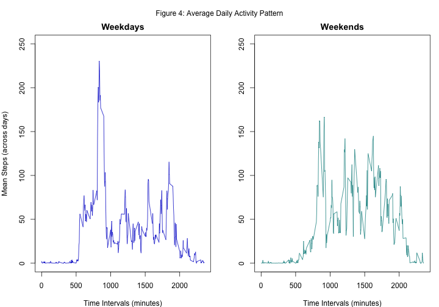

```r
## Add new column to data.frame calculating the day of week based on dates
imputedData$weekDay<- weekdays(imputedData$date)

## Replace days with weekday or weekend and converting the variable to a factor
for (i in 1: nrow(imputedData)){
    if (imputedData[i,4] == "Sunday" || imputedData[i,4] == "Saturday"){
        imputedData[i,4] <- "weekend"
    }
    else {
        imputedData[i,4]<- "weekday"
    }
}
imputedData$weekDay <- as.factor(imputedData$weekDay)

## Split the mean data by interval and by weekday/ weekend type
splitByDay <- tapply(imputedData$steps,list(imputedData$interval,imputedData$weekDay),FUN = mean)
splitByDay <- as.data.frame(splitByDay)

## Configure line plot panels to compare activity pattern on weekdays and weekends
par(mfrow = c(1,2), mar = c(4,4,2,1), oma = c(0,0,2,0))

## Setting ylim for easy comparison
plot(x = as.numeric(row.names(splitByDay)),y = splitByDay$weekday,type = "l",
     xlab = "Time Intervals (minutes)", ylab = "Mean Steps (across days)",
     main = "Weekdays", col = "blue3", ylim = c(0,250))

plot(x = as.numeric(row.names(splitByDay)),y = splitByDay$weekend,type = "l",
     xlab = "Time Intervals (minutes)", ylab = "", main = "Weekends",
     col = "cyan4", ylim = c(0,250))

mtext("Figure 4: Average Daily Activity Pattern",outer = TRUE)
```

```r
weekdaySum <- round(sum(splitByDay$weekday))
weekendSum <- round(sum(splitByDay$weekend))
```

On inspecting *Figure 4*, we see that:

1. Overall daily activity has shifted towards the later intervals during weekends as compared to weekdays.
2. Total steps on an Average weekday is approx. **10256** while Total steps on an Average weekend is approx. **12202**.